### A synthesis of the ten simple rules format in scientific discourse

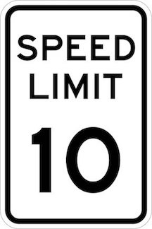

### Purpose

The primary goal here is to highlight that simple rules in science can strongly inform novice and expert scientists alike and provide a rapid roadmap to advance understanding for a specific topic. The impact is explored using conventional bibliometric estimates. Independent of the impact of these contributions to the peer-reviewed literature, this paper format can provide an overview of a topic and function as a mechanism to synthesize evidence. With the significant volume of scientific resoures available to the community including publications, data, blog posts, texts, vignettes, and technical resources, synthesis tools that succinctly direct, aggregate, and inform readers are increasingly important.

### Ten simple rules for rules

A summary of the salient elements common across all contributions.

1. Be useful.
2. Be clear.
3. Provide actionable rules .
4. List the best resources for additional research.
5. Be open.
6. Describe limitations and challenges of the rules provided.
7. Highlight the need within the field for synthesis.
8. Aggregate research and expert knowledge.
9. Be succinct.
10. Provide an outcome.

Contrast this topological assessment across all papers with the specific ten simple rules for simple rules paper. Consider using a checklist to score each and every contribution published to date with the proposed meta-rules (original and these).

### Data

```r
library(tidyverse)
library(skimr)
data <- read_csv("data/ten.simple.rules.scored.csv") #bibliometric returns from the Web of Science on June 25th, 2018

data <- data %>%
  select(title, authors, journal, year, DOI, total.citations, citations.yr, category, views, shares, saves)
data
```

```
## # A tibble: 99 x 11
##    title authors journal  year DOI   total.citations citations.yr category
##    <chr> <chr>   <chr>   <int> <chr>           <int>        <dbl> <chr>
##  1 Ten … Bourne… PLOS C…  2005 10.1…              19         1.36 research
##  2 Ten … Bourne… PLOS C…  2006 10.1…              13         1    communi…
##  3 Ten … Bourne… PLOS C…  2006 10.1…               8         0.62 profess…
##  4 Ten … Bourne… PLOS C…  2006 10.1…               0         0    profess…
##  5 Ten … Bourne… PLOS C…  2006 10.1…              21         1.62 research
##  6 Ten … Vicens… PLOS C…  2007 10.1…              19         1.58 collabo…
##  7 Ten … Erren,… PLOS C…  2007 10.1…              24         2    communi…
##  8 Ten … Bourne… PLOS C…  2007 10.1…              17         1.42 communi…
##  9 Ten … Grosch… PLOS C…  2007 10.1…               2         0.17 communi…
## 10 Ten … Erren,… PLOS C…  2007 10.1…               9         0.75 research
## # ... with 89 more rows, and 3 more variables: views <int>, shares <int>,
## #   saves <int>
```

```r
summary(data)
```

```
##     title             authors            journal               year
##  Length:99          Length:99          Length:99          Min.   :2005
##  Class :character   Class :character   Class :character   1st Qu.:2011
##  Mode  :character   Mode  :character   Mode  :character   Median :2015
##                                                           Mean   :2014
##                                                           3rd Qu.:2017
##                                                           Max.   :2018
##
##      DOI            total.citations   citations.yr      category
##  Length:99          Min.   :  0.00   Min.   : 0.000   Length:99
##  Class :character   1st Qu.:  0.00   1st Qu.: 0.000   Class :character
##  Mode  :character   Median :  4.00   Median : 0.750   Mode  :character
##                     Mean   : 12.03   Mean   : 1.765
##                     3rd Qu.:  9.50   3rd Qu.: 1.645
##                     Max.   :330.00   Max.   :36.670
##
##      views             shares           saves
##  Min.   :   1963   Min.   :   0.0   Min.   :   0.0
##  1st Qu.:   8736   1st Qu.:  23.0   1st Qu.:  50.0
##  Median :  22886   Median :  75.0   Median : 146.0
##  Mean   :  65119   Mean   : 209.7   Mean   : 313.9
##  3rd Qu.:  46847   3rd Qu.: 202.0   3rd Qu.: 329.0
##  Max.   :1132219   Max.   :3024.0   Max.   :3263.0
##  NA's   :10        NA's   :10       NA's   :10
```

```r
#PCOMPBIO only
pcomp <- data %>%
  filter(journal == "PLOS COMPUTATIONAL BIOLOGY")
summary(pcomp)
```

```
##     title             authors            journal               year
##  Length:94          Length:94          Length:94          Min.   :2005
##  Class :character   Class :character   Class :character   1st Qu.:2011
##  Mode  :character   Mode  :character   Mode  :character   Median :2015
##                                                           Mean   :2014
##                                                           3rd Qu.:2017
##                                                           Max.   :2018
##
##      DOI            total.citations    citations.yr      category
##  Length:94          Min.   :  0.000   Min.   : 0.000   Length:94
##  Class :character   1st Qu.:  0.000   1st Qu.: 0.000   Class :character
##  Mode  :character   Median :  4.000   Median : 0.750   Mode  :character
##                     Mean   :  7.277   Mean   : 1.268
##                     3rd Qu.:  9.000   3rd Qu.: 1.560
##                     Max.   :111.000   Max.   :18.500
##
##      views             shares           saves
##  Min.   :   1963   Min.   :   0.0   Min.   :   0.0
##  1st Qu.:   8736   1st Qu.:  23.0   1st Qu.:  50.0
##  Median :  22886   Median :  75.0   Median : 146.0
##  Mean   :  65119   Mean   : 209.7   Mean   : 313.9
##  3rd Qu.:  46847   3rd Qu.: 202.0   3rd Qu.: 329.0
##  Max.   :1132219   Max.   :3024.0   Max.   :3263.0
##  NA's   :5         NA's   :5        NA's   :5
```

```r
skim(pcomp)
```

```
## Skim summary statistics
##  n obs: 94
##  n variables: 11
##
## ── Variable type:character ────────────────────────────────────
##  variable missing complete  n min max empty n_unique
##   authors       0       94 94   9 356     0       87
##  category       0       94 94   4  24     0        8
##       DOI       0       94 94  28  28     0       94
##   journal       0       94 94  26  26     0        1
##     title       0       94 94  30  95     0       94
##
## ── Variable type:integer ──────────────────────────────────────
##         variable missing complete  n     mean        sd   p0  p25   p50
##            saves       5       89 94   313.85    521.13    0   50   146
##           shares       5       89 94   209.72    433.81    0   23    75
##  total.citations       0       94 94     7.28     13.05    0    0     4
##            views       5       89 94 65119.45 155747.65 1963 8736 22886
##             year       0       94 94  2013.61      3.6  2005 2011  2015
##    p75    p100     hist
##    329    3263 ▇▁▁▁▁▁▁▁
##    202    3024 ▇▁▁▁▁▁▁▁
##      9     111 ▇▁▁▁▁▁▁▁
##  46847 1132219 ▇▁▁▁▁▁▁▁
##   2017    2018 ▂▂▁▃▃▃▇▇
##
## ── Variable type:numeric ──────────────────────────────────────
##      variable missing complete  n mean  sd p0 p25  p50  p75 p100     hist
##  citations.yr       0       94 94 1.27 2.2  0   0 0.75 1.56 18.5 ▇▁▁▁▁▁▁▁
```

```r
#quick count within categories####
#Categories were assigned to general domains of the scientific process using the abstracts and familiarity with each publication (but not with detailed inspection). A secondary classification was also applicable in many instances, and the assignments provided were the primary focus of the paper - i.e. collaboration in a specific field would be classified as collaboration only using this schema.

cats <- data %>%
  group_by(year, category) %>%
  count()
cats
```

```
## # A tibble: 57 x 3
## # Groups:   year, category [57]
##     year category                     n
##    <int> <chr>                    <int>
##  1  2005 research                     1
##  2  2006 communication                1
##  3  2006 professional development     2
##  4  2006 research                     1
##  5  2007 collaboration                1
##  6  2007 communication                3
##  7  2007 research                     2
##  8  2008 collaboration                1
##  9  2008 research                     1
## 10  2008 statistics                   1
## # ... with 47 more rows
```

### Viz

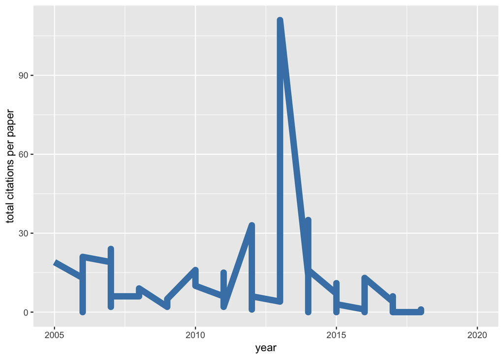

```r
#all pcombbiol papers####
ggplot(pcomp, aes(year, total.citations)) +
  geom_line(color = "steelblue", size = 3) +
  xlim(c(2005, 2020)) +
  labs(x = "year", y = "total citations per paper")
```

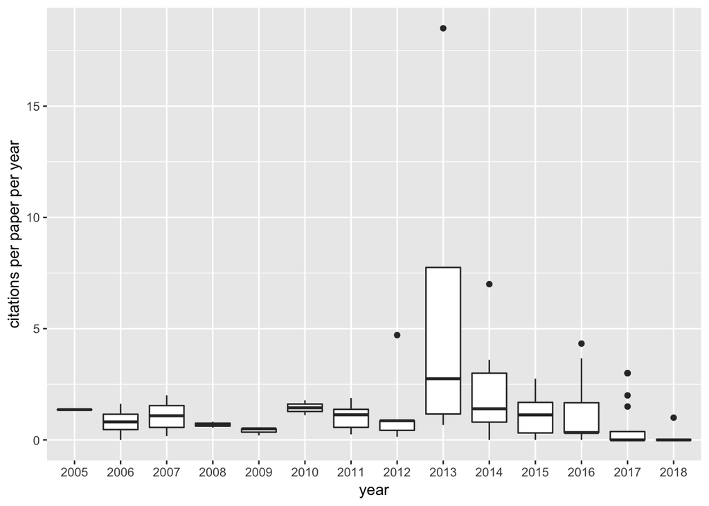

```r
ggplot(pcomp, aes(as.character(year), citations.yr)) +
  geom_boxplot() +
  labs(x = "year", y = "citations per paper per year")
```

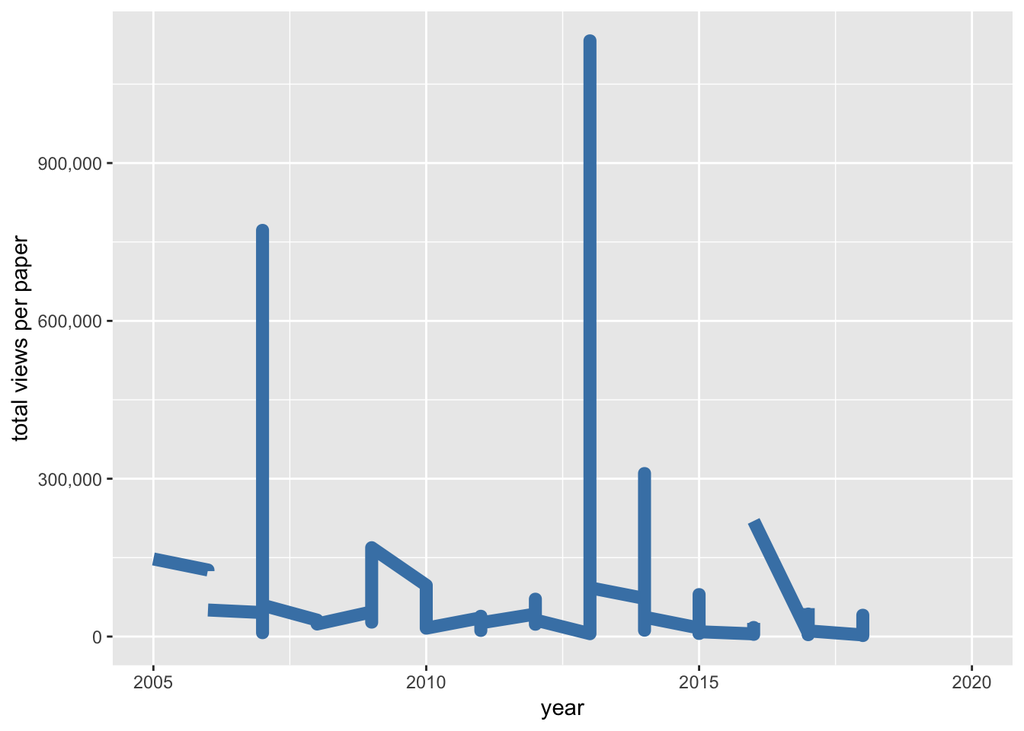

```r
#views
ggplot(pcomp, aes(year, views)) +
  geom_line(color = "steelblue", size = 3) +
  xlim(c(2005, 2020)) +
  labs(x = "year", y = "total views per paper") +
  scale_y_continuous(labels = scales::comma)
```

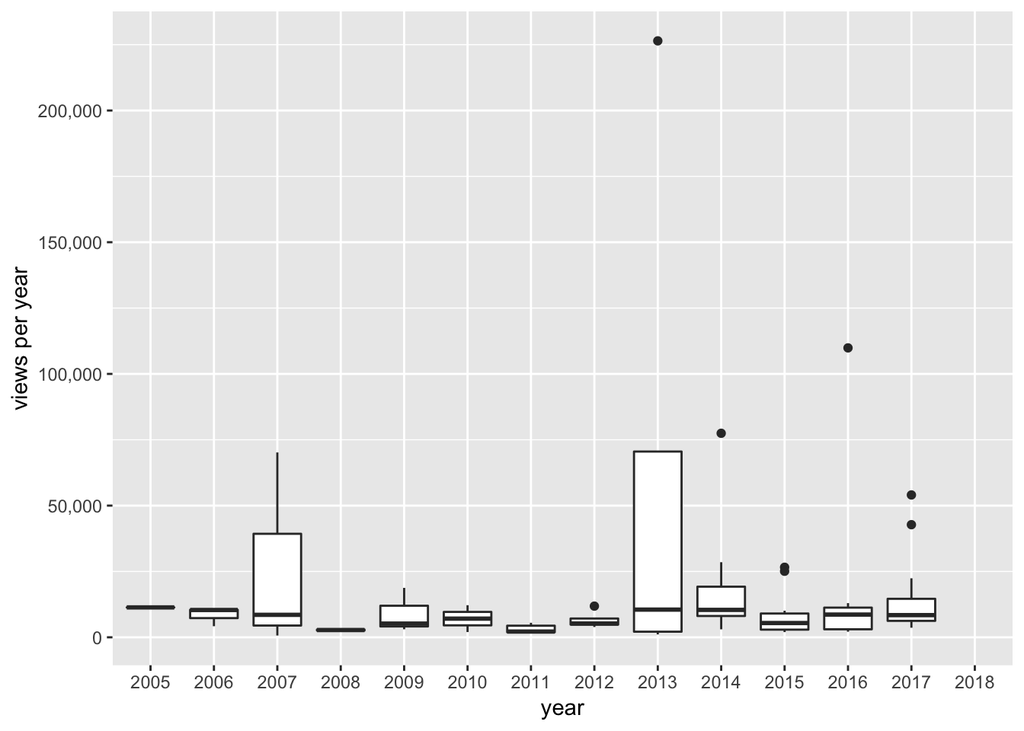

```r
ggplot(pcomp, aes(as.character(year), (views/(2018-year)))) +
  geom_boxplot() +
  labs(x = "year", y = "views per year") +
  scale_y_continuous(labels = scales::comma)
```

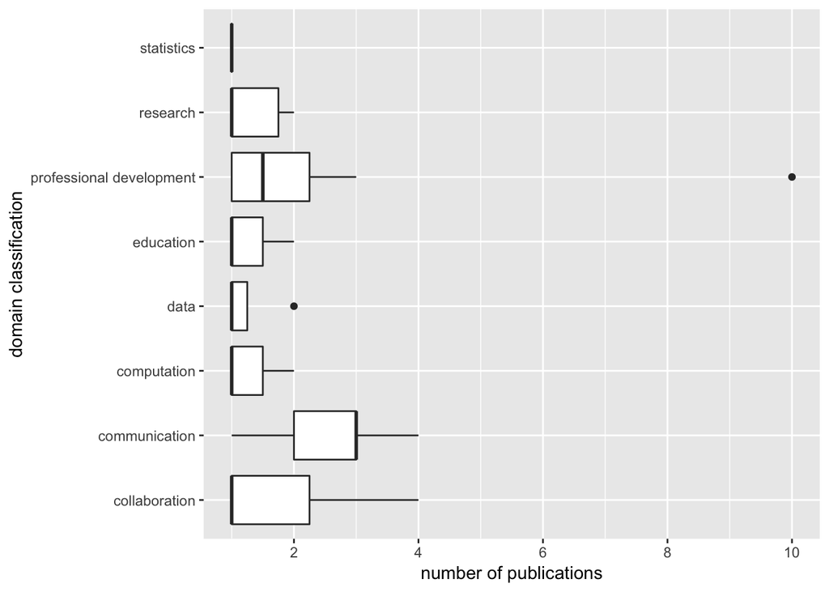

```r
#by category
ggplot(cats, aes(category, n)) +
  geom_boxplot() +
  labs(x = "domain classification", y = "number of publications") +
  scale_y_continuous(breaks=seq(0,10,2)) +
  coord_flip()
```

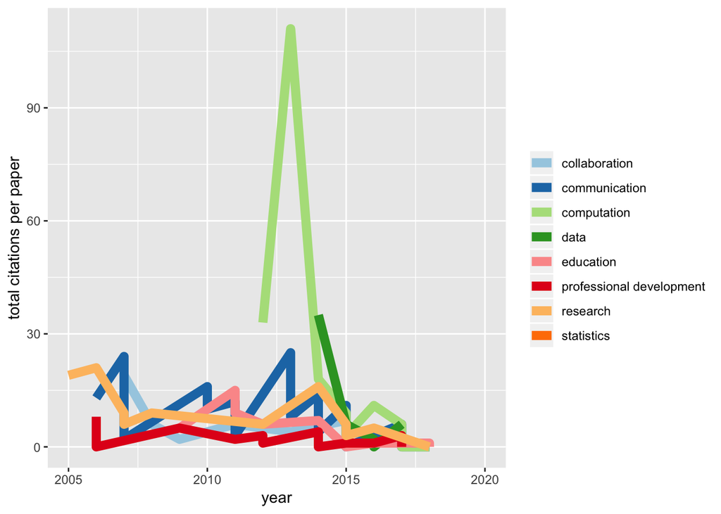

```r
ggplot(pcomp, aes(year, total.citations, color = category)) +
  geom_line(size = 3) +
  xlim(c(2005, 2020)) +
  labs(x = "year", y = "total citations per paper", color = "") +
  scale_color_brewer(palette = "Paired")
```

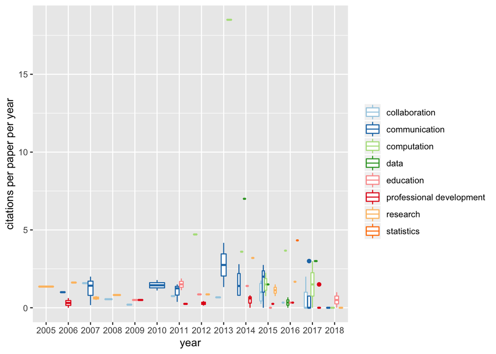

```r
ggplot(pcomp, aes(as.character(year), citations.yr, color = category)) +
  geom_boxplot() +
  labs(x = "year", y = "citations per paper per year", color = "") +
  scale_color_brewer(palette = "Paired")
```

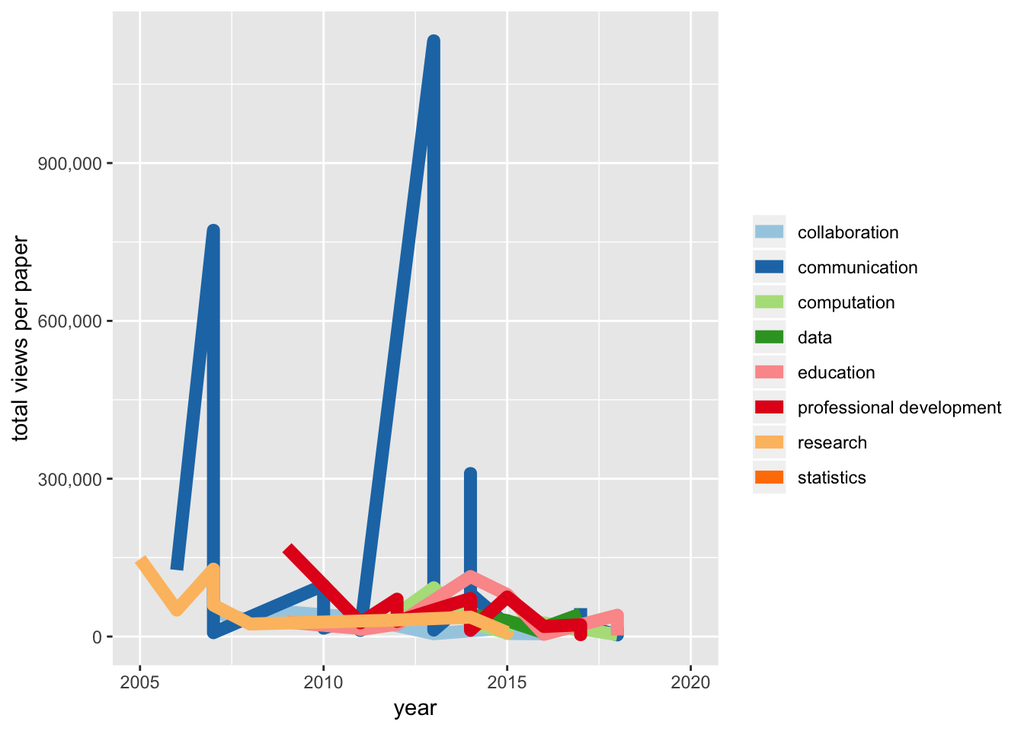

```r
#views
ggplot(pcomp, aes(year, views, color = category)) +
  geom_line(size = 3) +
  xlim(c(2005, 2020)) +
  labs(x = "year", y = "total views per paper", color = "") +
  scale_color_brewer(palette = "Paired") +
  scale_y_continuous(labels = scales::comma)
```

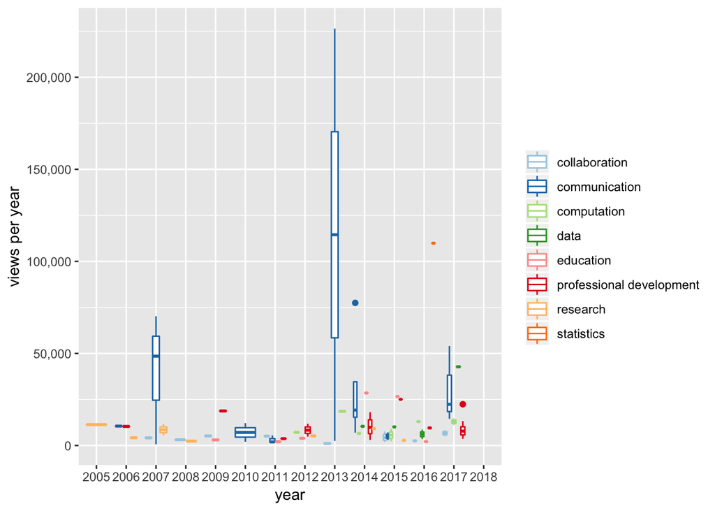

```r
ggplot(pcomp, aes(as.character(year), (views/(2018-year)), color = category)) +
  geom_boxplot() +
  labs(x = "year", y = "views per year", color = "") +
  scale_color_brewer(palette = "Paired") +
  scale_y_continuous(labels = scales::comma)
```

### Ideas

1. Uptake in teaching contexts.
2. Presentations and slide decks that are often used to communicate and further share the rules.
3. Secure altmetric measures of performance for each paper, i.e. 22,000 views on a given ten simple rules papers is a significant contribution to the community.
4. Summarize the success of the most ‘successful’ papers, highlight salient elements across all papers, and do a narrative review of summary of the breadth of the field.
5. Scrape first author data for each publication.
6. Map countries associated with each contribution.
7. Provide an infographic.
8. Develop a checklist using ten simple rules for rules.

### Observations

1. Currently, there is a total of 99 ‘ten simple rules’ publications with 94 in PCOMPBIO.
2. The first paper in PCOMPBIO was published in 2005, the mean of total citations per instance is 7.3 (median 4), and the mean citations per year per instance is 1.3.
3. There was peak in citation activity centered around the year 2013 in both total citations and citations per paper.
4. Ten simple rules publications directly related to computation are very successful in securing citations.
5. There are nonetheless many categories of ten simple rules contributions that synthesize almost every aspect of the scientific progress from mechanistic details of research to professional development.